# Exercice I.6

La fonction $f$ est d??rivable, sa d??riv??e est $f'(x)=3(x-1)^2\geq0$, d'o?? $f$ est strictement croissante sur $I:={]-\infty,1]}$. De plus $f(x)\to-\infty$ lorsque $x\to-\infty$, et $f(1)=0$.

Ainsi, l'image de $I$ par $f$ est $]-\infty,0]\subset I$, et la stabilit?? de $I$ par $f$. Enfin, $$\forall n\in\mathbb N, \ u_n\in I.$$

On a $g(x)=(x-1)^3-x$, d'o?? $g$ est d??rivable de d??riv??e $g'(x)=3(x-1)^2-1 = 3x^2-6x+2 = 3\left(x-1-\frac{\sqrt 3}{3}\right)\left(x-1+\frac{\sqrt 3}{3}\right)$. Donc $g$ a pour maximum sur $I$ le r??el $g\left(1-\frac{\sqrt 3}{3}\right) = \frac{2}{3\sqrt 3}-1<0$, d'o?? $g<0$ sur $I$.

On en d??duit que $\forall n\in\mathbb N,\ u_{n+1}-u_n = g(u_n)<0$: $(u_n)$ est strictement d??croissante.

On a deux cas de figure : $u$ minor??e (et donc converge vers un r??el $\ell < u_0 \leq 1$), et $u$ non minor??e (et donc $u_n\to-\infty$).

Si $u$ est minor??e, elle admet une limite finie $\ell\in I$ qui v??rifie alors $f(\ell)=\ell$ i.e. $g(\ell)=0$, mais $g<0$ sur $I$: absurde.
Donc $u$ n'est pas minor??e, $$u_n\xrightarrow[n\to+\infty]{}-\infty. $$

# Exercice I.7

Soit $f:\mathbb R\longrightarrow\mathbb R,\;x\longmapsto -(x-2)^2+2$.

??tudions le signe de $g:x\longmapsto f(x)-x$ sur ${]-\infty,2]}$. On a $g(x)=-(x-2)^2+2-x = -x^2+3x-2 = -(x-1)(x-2)$ pour tout $x \leq 2$, d'o?? $1$ et $2$ sont les seuls points fixes de $f$, et le tableau de signe suivant:

| $x$ | $-\infty\qquad 1$ | $\hphantom{1}\qquad 2$ |
| --- | --- | --- |
| $g(x)$ | $-$ | $+$ |

Pour finir, un petit aper??u du comportement de $(u_n)$ avec diverses valeurs de $u_0$ :

```python
%matplotlib inline
import matplotlib.pyplot as plt

def f(x):
    '''Fonction de r??currence f'''
    return -(x-2)**2+2

def flot(u0,n):
    '''Construit les n premiers termes de la suite
    de premier terme u0 v??rifiant u_n+1 = f(u_n)'''
    L = [u0]
    for i in range(n): # construit les n premiers termes
        terme = L[-1]
        term_suiv = f(terme)
        L.append(term_suiv)
    return L
```

```python
def build_flow(prems,nmaxs,placement):
    """Construction des graphes des suites (u_n)"""
    nb_g = max(placement)+1
    fig,ax = plt.subplots(nb_g,1, figsize=(8,8))
    for i,[p, s, u0] in enumerate(zip(placement,styl,prems)):
        ax[p].plot(flot(u0,nmaxs[p]),s,label=r'$u_0={}$'.format(u0))
        # ajoute les points de la liste L au graphe
    for axi in ax:
        axi.grid()
        axi.legend(loc=0)
        axi.margins(y=0.06) # marge additionnelle sur l'axe des ordonn??es
        axi.set_xlabel(r'$n$') # titre axe des abscisses
        axi.set_ylabel(r'$u_n$') # titre axe des ordonn??es
```

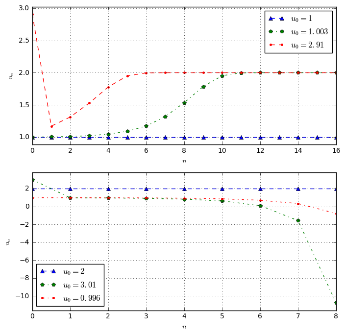

```python
prems = [1, 2, 1.003, 2.91, 3.01, 0.996]
nmaxes = [16, 8]
placement = [0, 1, 0, 0, 1, 1]
styl = ['^--', '^--', 'p-.', '--.', 'p-.', '.-.']
build_flow(prems,nmaxes,placement)
```